# Tutorial for `MDRefine` - 1

Refinement of the structural ensembles and forward models

In these notebooks we are going to perform several different refinements of MD-generated trajectories by employing the package `MDRefine`. In this way, we believe the usage of `MDRefine` will become clear and easy to emulate for your own case of interest.

We remind you to have a look at our paper https://arxiv.org/pdf/2411.07798 and at the documentation https://www.bussilab.org/doc-MDRefine/MDRefine/index.html.

Required assistance may be opened at https://github.com/bussilab/MDRefine/issues.

```python
# install matplotlib and other dependencies
!pip install -r requirements.txt
```

```python
import numpy as np
import jax.numpy as jnp
import pandas
import matplotlib
import matplotlib.pyplot as plt
from IPython.display import clear_output
```

```python
# import from parent directory
import sys
sys.path.insert(0, '../')

import MDRefine

print("I will use the MDRefine version installed at", MDRefine.__file__)
```

```
I will use the MDRefine version installed at /home/runner/work/MDRefine/MDRefine/Examples/../MDRefine/__init__.py
```

```python
from MDRefine import load_data, minimizer, split_dataset, hyper_minimizer, MDRefinement, unwrap_dict
```

## 1. Ensemble refinement

In this section, we are going to reproduce results from *T. Fröhlking et al., "Simultaneous refinement of molecular dynamics ensembles and forward models using experimental data", J. Chem. Phys. 158, 214120 (2023)* https://pubs.aip.org/aip/jcp/article/158/21/214120/2894410.

They regard the refinement of the structural ensembles of RNA oligomers (Ensemble Refinement based on the max. entropy principle), with possible flexibility on the forward models (Karplus equations).

```python
%%bash

if [ ! -d "DATA" ]; then
    echo "download DATA from Zenodo"
    curl -O https://zenodo.org/records/14956459/files/DATA.zip

    unzip DATA.zip
    rm -r DATA.zip
fi
```

```
download DATA from Zenodo
```

[output not shown]

[output not shown]

[output not shown]

[output not shown]

[output not shown]

[output not shown]

[output not shown]

[output not shown]

[output not shown]

[output not shown]

[output not shown]

[output not shown]

[output not shown]

[output not shown]

[output not shown]

[output not shown]

[output not shown]

[output not shown]

[output not shown]

[output not shown]

[output not shown]

[output not shown]

[output not shown]

[output not shown]

[output not shown]

[output not shown]

[output not shown]

[output not shown]

[output not shown]

[output not shown]

[output not shown]

[output not shown]

[output not shown]

[output not shown]

[output not shown]

[output not shown]

[output not shown]

[output not shown]

[output not shown]

[output not shown]

[output not shown]

[output not shown]

[output not shown]

[output not shown]

[output not shown]

[output not shown]

[output not shown]

[output not shown]

[output not shown]

[output not shown]

[output not shown]

[output not shown]

[output not shown]

[output not shown]

[output not shown]

[output not shown]

[output not shown]

[output not shown]

[output not shown]

[output not shown]

[output not shown]

[output not shown]

[output not shown]

[output not shown]

[output not shown]

[output not shown]

[output not shown]

[output not shown]

[output not shown]

[output not shown]

[output not shown]

[output not shown]

[output not shown]

[output not shown]

[output not shown]

[output not shown]

[output not shown]

[output not shown]

[output not shown]

[output not shown]

[output not shown]

[output not shown]

[output not shown]

[output not shown]

[output not shown]

[output not shown]

[output not shown]

[output not shown]

[output not shown]

[output not shown]

[output not shown]

[output not shown]

[output not shown]

[output not shown]

[output not shown]

[output not shown]

[output not shown]

[output not shown]

[output not shown]

[output not shown]

[output not shown]

[output not shown]

[output not shown]

[output not shown]

[output not shown]

[output not shown]

[output not shown]

[output not shown]

[output not shown]

[output not shown]

[output not shown]

[output not shown]

[output not shown]

[output not shown]

[output not shown]

[output not shown]

[output not shown]

[output not shown]

[output not shown]

[output not shown]

[output not shown]

[output not shown]

[output not shown]

[output not shown]

[output not shown]

[output not shown]

[output not shown]

[output not shown]

[output not shown]

[output not shown]

[output not shown]

[output not shown]

[output not shown]

[output not shown]

[output not shown]

[output not shown]

[output not shown]

[output not shown]

[output not shown]

[output not shown]

[output not shown]

[output not shown]

[output not shown]

[output not shown]

[output not shown]

[output not shown]

[output not shown]

[output not shown]

[output not shown]

[output not shown]

[output not shown]

[output not shown]

[output not shown]

[output not shown]

[output not shown]

[output not shown]

[output not shown]

[output not shown]

[output not shown]

[output not shown]

[output not shown]

[output not shown]

[output not shown]

[output not shown]

[output not shown]

[output not shown]

[output not shown]

[output not shown]

[output not shown]

[output not shown]

[output not shown]

[output not shown]

[output not shown]

[output not shown]

[output not shown]

[output not shown]

[output not shown]

[output not shown]

[output not shown]

[output not shown]

[output not shown]

[output not shown]

### a. Load data

In order to perform the refinement, we first need to store the data from MD simulations and experiments in a directory structured as described in https://arxiv.org/pdf/2411.07798 - *Structure of `data` objects*. Then, we can define the `infos` dictionary, which informs about which input files are going to be read, and run the `load_data` function.

The output of `load_data` is a class instance `data` with all the quantities required in the following steps (see again Section *Structure of `data` objects*).

- 1. Just load the observables (without force-field terms nor forward quantities)

```python
infos = {}

# Firstly, define global properties, valid for all the systems:

infos['global'] = {}

# 'name of the folder with data'
infos['global']['path_directory'] = 'DATA'

# system names
system_names = ['AAAA', 'CAAU']  # , 'CCCC', 'GACC', 'UUUU', 'UCAAUC']
infos['global']['system_names'] = system_names

# Then, define properties which are specific of each system, like experimental data and observables

for name in system_names:
    infos[name] = {}

    # experimental observables (average and uncertainty), corresponding to 'file_name'.npy in DATA/system_name/g_exp/
    # uNOEs values are upper bounds, so specify '<' with ('uNOEs','<')
    infos[name]['g_exp'] = ['NOEs', ('uNOEs','<')]

    # observables from MD simulations, corresponding to 'file_name'.npy in DATA/system_name/observables/
    # they must correspond also to items of infos[name]['g_exp']
    infos[name]['obs'] = ['NOEs', 'uNOEs']

# If some properties are the same for all the systems, you can store them just once in infos['global']

infos['global']['temperature'] = 1 # namely, energies are in unit of k_B T (default value)
# (in this case, you could do this also for 'g_exp' and 'obs')

# Select the stride for the frames (thinner strides will require more time for minimizations; default value = 1)
stride = 10
```

- 2. Include also quantities computed through the defined forward model

```python
for name in system_names:
    # include experimental values also for 3J scalar couplings
    infos[name]['g_exp'] = ['backbone1_gamma_3J', 'backbone2_beta_epsilon_3J', 'sugar_3J', 'NOEs', ('uNOEs','<')]

    # include quantities required to compute observables through the forward model
    # they must correspond to 'file_name'.npy in DATA/system_name/forward_qs/
    infos[name]['forward_qs'] = ['backbone1_gamma','backbone2_beta_epsilon','sugar']

# starting values of the forward model coefficients: specify the file name inside DATA/
infos['global']['forward_coeffs'] = 'original_fm_coeffs' # string
```

Now, let's define the **forward model**.

In our case-study, the forward model is given by the **Karplus equations**:

$^3 J_\gamma = A_\gamma \, cos^2\gamma \, + \, B_\gamma \, cos\gamma \, + \, C_\gamma$

with empirical coefficients $A_\gamma,\,B_\gamma,\,C_\gamma$ ($\gamma$ dihedral angles), and analogously for $^3 J_{\beta/\epsilon}$ (same coefficients both for $\beta$ and $\epsilon$ dihedral angles) and $^3J_\nu$ (sugar dihedral angles).

**WARNING**: `forward_model_fun` returns a dict `forward_qs_out` whose keys must correspond to those of the associated experimental values `g_exp`, as specified in `infos`.

```python
def forward_model_fun(fm_coeffs, forward_qs, selected_obs = None):

    # 1. compute the cosine (which is the quantity you need in the forward model;
    # you could do this just once before loading data)
    forward_qs_cos = {}

    for type_name in forward_qs.keys():
        forward_qs_cos[type_name] = np.cos(forward_qs[type_name])

    # if you have selected_obs, compute only the corresponding observables
    if selected_obs is not None:
        for type_name in forward_qs.keys():
            forward_qs_cos[type_name] = forward_qs_cos[type_name][:,selected_obs[type_name+'_3J']]

    # 2. compute observables (forward_qs_out) through forward model
    forward_qs_out = {
        'backbone1_gamma_3J': fm_coeffs[0]*forward_qs_cos['backbone1_gamma']**2 + fm_coeffs[1]*forward_qs_cos['backbone1_gamma'] + fm_coeffs[2],
        'backbone2_beta_epsilon_3J': fm_coeffs[3]*forward_qs_cos['backbone2_beta_epsilon']**2 + fm_coeffs[4]*forward_qs_cos['backbone2_beta_epsilon'] + fm_coeffs[5],
        'sugar_3J': fm_coeffs[6]*forward_qs_cos['sugar']**2 + fm_coeffs[7]*forward_qs_cos['sugar'] + fm_coeffs[8]}

    return forward_qs_out
```

```python
# same forward-model function for each system, so store it in infos['global']
infos['global']['forward_model'] = forward_model_fun
```

```python
data = load_data(infos, stride=stride)
```

```
loading data from directory...
```

```
loading  AAAA
```

```
loading  CAAU
```

```
done
```

### b. Minimize the loss function and analyse the results

for a single choice of the hyper-parameter $\alpha$

Namely, let's perform ensemble refinement with a given value of the hyperparameter $\alpha$, representing the strength to the original ensembles generated from the MD simulations.

```python
# use function minimizer with selected data and alpha as input
Result = minimizer(data, alpha=1)
```

[output not shown]

`minimizer` returns a class instance `Result`, let's have a look at it

```python
print(vars(Result).keys())
```

```
dict_keys(['loss', 'min_lambdas', 'minis', 'time', 'D_KL_alpha', 'abs_difference', 'av_g', 'chi2', 'logZ_new', 'weights_new'])
```

```python
# check the convergence
for name_sys in data.properties.system_names:
    print(Result.minis[name_sys].success, Result.minis[name_sys].message)

# min. value of the loss function
print('optimal loss: ', Result.loss)
print('time required: ', Result.time)

# Kullback-Leibler divergence
print('D_KL: ', Result.D_KL_alpha)
```

```
True CONVERGENCE: NORM OF PROJECTED GRADIENT <= PGTOL
True CONVERGENCE: NORM OF PROJECTED GRADIENT <= PGTOL
optimal loss:  22.04173298062923
time required:  4.281575918197632
D_KL:  {'AAAA': Array(2.89326568, dtype=float64), 'CAAU': Array(2.94441586, dtype=float64)}
```

- then, let's look at the optimal ensembles $P^*$ **weights_new** (completely defined by the starting ensembles and by the **min_lambdas** coefficients), together with their (log) normalization factor **logZ_new**. Let's plot them.

```
system AAAA:
effective n. of frames (on the total n.):  0.055395014783666985
logZ:  -48.83564525939043
system CAAU:
effective n. of frames (on the total n.):  0.05263279566112816
logZ:  -25.626407291911043
```

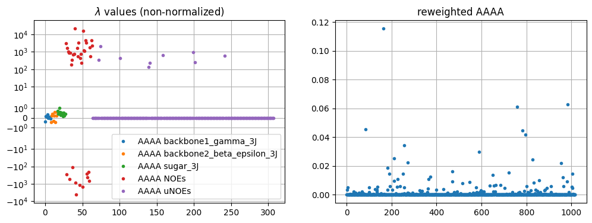

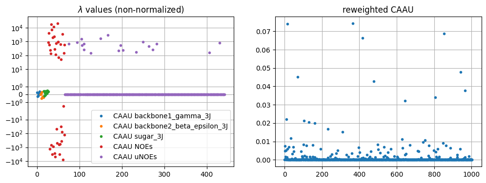

```python
for s in system_names:

    plt.figure(figsize = (12,4))

    plt.subplot(1,2,1)

    l = 0
    for i2,s2 in enumerate(Result.min_lambdas[s].keys()):
        l_new = l+len(Result.min_lambdas[s][s2])
        plt.plot(np.arange(l,l_new),Result.min_lambdas[s][s2],'.',label='%s %s' % (s,s2))
        l = l_new

    plt.title('$\lambda$ values (non-normalized)')
    plt.legend()# loc='center left', bbox_to_anchor=(1, 0.5))
    plt.grid()
    plt.yscale('symlog')

    plt.subplot(1,2,2)

    plt.plot(Result.weights_new[s],'.')
    plt.title('reweighted %s' % s)
    plt.grid()

    n_eff = np.exp(-Result.D_KL_alpha[s])

    print('system %s:' % s)
    print('effective n. of frames (on the total n.): ', n_eff)
    print('logZ: ', Result.logZ_new[s])
```

- finally, let's look at the average values of the observables in the new ensembles **av_g** and associated **chi2**; compare with experimental values gexp and with average values of the original ensembles.

```
chi2:  7.544855832915589
observables (first names in list):
 [["A1-H1'" 'A1-H8']
 ["A1-H1'" 'A2-H8']
 ['A1-H2' "A2-H1'"]
 ["A1-1H2'" 'A1-H8']
 ["A1-1H2'" "A2-H1'"]]
```

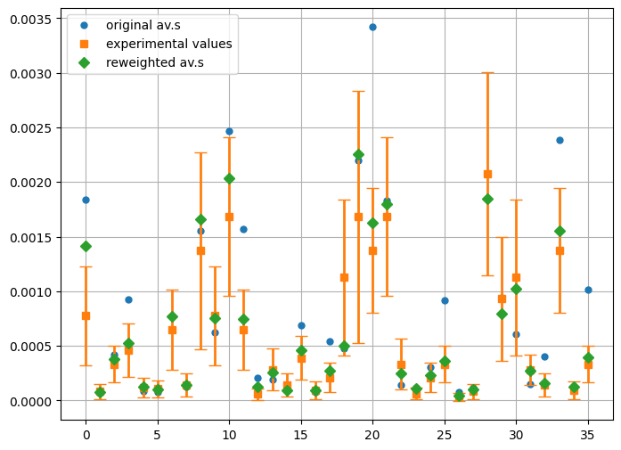

```python
s1 = 'AAAA'
s2 = 'NOEs'

print('chi2: ',Result.chi2[s1][s2])
print('observables (first names in list):\n',data.mol[s1].names[s2][:5])

plt.figure(figsize=(8,6))

# compute average values with original ensemble
g_mean = np.matmul(data.mol[s1].weights, data.mol[s1].g[s2])

plt.plot(g_mean,'.',label='original av.s',markersize=10)

plt.plot(data.mol[s1].gexp[s2][:,0],'s',label='experimental values')
plt.errorbar(np.arange(len(data.mol[s1].gexp[s2][:,0])), data.mol[s1].gexp[s2][:,0], data.mol[s1].gexp[s2][:,1], fmt = ' ',
    color = 'tab:orange', capsize = 5, lw = 2)

plt.plot(Result.av_g[s1][s2], 'D', label = 'reweighted av.s')

plt.legend()
plt.grid()
```

### c. Determine optimal hyper parameter $\alpha$ through cross validation (scan over $\alpha$)

The hyperparameter $\alpha$ tunes the reliability given to the original ensemble in spite of the trust to experimental data.

Suitable values of $\alpha$ can be determined through a **cross validation procedure**: randomly split the full data set into training and validation set, then select the value of $\alpha$ which minimizes the $\chi^2$ on the validation set (either same observables as in training but new frames or new observables); repeat over several splittings.

For the moment, let's perform just one splitting into training/validation set (as an example) and scan over different values of $\alpha$ (in logarithmic scale).

The function **split_dataset** can be used to get **data_train** and **data_valid** by simply passing a **random_state** (a random integer), which randomly selects **valid_obs** and **valid_frames**.

```python
# split into data_cv (for cross validation) and data_test

data_cv, data_test, test_obs, test_frames = split_dataset(data, frames_fraction=0)
# data_train, data_valid, valid_obs, valid_frames = split_dataset(data_train_and_valid, random_state=1)
```

```
split observables only (not frames)
random state:  113
Input random_state employed for observables only
```

```python
data_train, data_valid, valid_obs, valid_frames = split_dataset(data_cv, random_state=1)
```

```
Input random_state employed both for observables and frames
```

```python
data_train, data_valid, valid_obs, valid_frames = split_dataset(data, random_state=1)
```

```
Input random_state employed both for observables and frames
```

```python
print(data.properties.tot_n_experiments(data))
print(data_test.properties.tot_n_experiments(data_test))
print(data_cv.properties.tot_n_experiments(data_cv))

print(data_valid.properties.tot_n_experiments(data_valid))
print(data_train.properties.tot_n_experiments(data_train))
```

```
751
151
600
600
600
```

```python
s = 'NOEs'

print(data.mol['AAAA'].g[s].shape)
print(data_train.mol['AAAA'].g[s].shape)
print(data_valid.mol['AAAA'].g[s].shape)
print(data_valid.mol['AAAA'].g_new[s].shape)

print(data_cv.mol['AAAA'].g[s].shape)
print(data_test.mol['AAAA'].g[s].shape)
```

```
(1017, 36)
(814, 30)
(203, 30)
(203, 6)
(1017, 25)
(1017, 11)
```

```python
n_tot_exp = data.properties.tot_n_experiments(data)
n_valid_exp = len(unwrap_dict(valid_obs))

n_train_exp = n_tot_exp - n_valid_exp

print('tot. n. of observables: ', n_tot_exp)
print('n. of validation observables: ', n_valid_exp)
print('n. of training observables', n_train_exp)
```

```
tot. n. of observables:  751
n. of validation observables:  151
n. of training observables 600
```

```python
# You can also select different values from the default ones
data_train, data_valid, valid_obs, valid_frames = split_dataset(data, frames_fraction=0.2, obs_fraction=0.3,
    random_state=4, if_all_frames=True)
```

```
Input random_state employed both for observables and frames
```

```python
# Alternatively, you can also directly pass valid_obs and valid_frames.
out = split_dataset(data, valid_obs=valid_obs, valid_frames=valid_frames)

data_train = out[0]
data_valid = out[1]
```

```
Input random_state will not be used
```

In any case, you can now scan over different values of $\alpha$ for a given partition of the full data set into training and validation set. Let's work directly with logarithms in base 10, in order to explore several orders of magnitude for $\alpha$.

Let's pass `data_valid` as input to `minimizer`: after the minimization of the loss function on `data_train`, relevant properties (such as $D_{KL}$, $\chi^2$, loss function) are evaluated on the validation frames and a further $\chi^2$ is evaluated on validation observables.

```python
log10_alphas = np.arange(-2, 7, 1)

Results = {}

for log10_alpha in log10_alphas:
    print(log10_alpha)

    alpha = 10**np.float64(log10_alpha)
    Results[log10_alpha] = minimizer(data_train, alpha=alpha, data_valid=data_valid)

    clear_output()
```

```python
vars(Results[log10_alpha]).keys()
```

```
dict_keys(['loss', 'min_lambdas', 'minis', 'time', 'D_KL_alpha', 'abs_difference', 'av_g', 'chi2', 'logZ_new', 'weights_new', 'loss_valid', 'D_KL_alpha_valid', 'abs_difference_valid', 'av_g_valid', 'chi2_valid', 'logZ_new_valid', 'weights_new_valid', 'avg_new_obs', 'chi2_new_obs'])
```

For each value of the hyperparameter $\alpha$, we now have corresponding quantities for validation frames (such as **loss_valid**, **D_KL_alpha_valid**, **av_g_valid**, **chi2_valid**, **weights_new_valid**) and for validation observables (**avg_new_obs** and **chi2_new_obs**).

Let's compare the loss function for training set and validation set (new frames):

- at high values of $\alpha$, the two values almost overlap;
- decreasing $\alpha$, both the two loss functions decrease, except that the one on the validation at a certain point starts to increase marking overfitting.

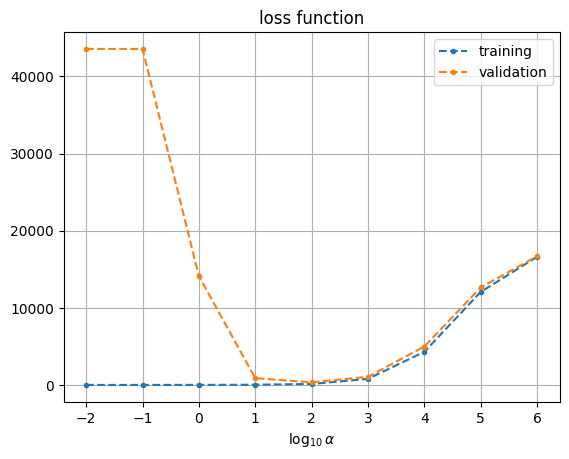

```python
loss = [Results[log10_alpha].loss for log10_alpha in log10_alphas]
loss_valid = [Results[log10_alpha].loss_valid for log10_alpha in log10_alphas]

plt.title('loss function')
plt.plot(log10_alphas, loss, '.--', label = 'training')
plt.plot(log10_alphas, loss_valid, '.--', label = 'validation')
plt.xlabel(r'$\log_{10}\alpha$')
plt.legend()
plt.grid()
```

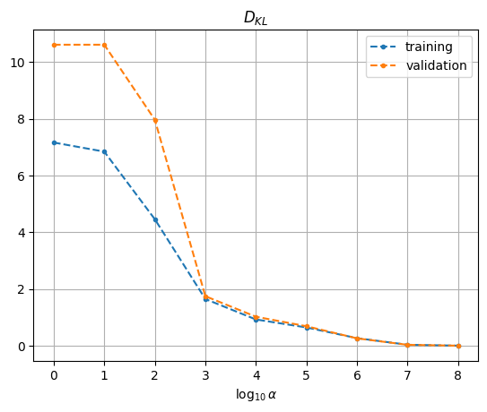

```python
D_KL_train = [np.sum(unwrap_dict(Results[log10_alpha].D_KL_alpha)) for log10_alpha in log10_alphas]
D_KL_valid = [np.sum(unwrap_dict(Results[log10_alpha].D_KL_alpha_valid)) for log10_alpha in log10_alphas]

plt.title('$D_{KL}$')
plt.plot(D_KL_train, '.--', label = 'training')
plt.plot(D_KL_valid, '.--', label = 'validation')
plt.xlabel(r'$\log_{10}\alpha$')
plt.legend()
plt.grid()
```

Now, the $\chi^2$, including also validation observables

```python
chi2s = [np.sum(unwrap_dict(Results[log10_alpha].chi2)) for log10_alpha in log10_alphas]
n_obs_train = data_train.properties.tot_n_experiments(data_train)

red_chi2s = np.array(chi2s)/n_obs_train

chi2s_valid1 = [np.sum(unwrap_dict(Results[log10_alpha].chi2_valid)) for log10_alpha in log10_alphas]  # .chi2_valid
red_chi2s_valid1 = np.array(chi2s_valid1)/n_obs_train

chi2s_valid2 = [np.sum(unwrap_dict(Results[log10_alpha].chi2_new_obs)) for log10_alpha in log10_alphas]  # .chi2_valid
n_obs_valid = len(unwrap_dict(valid_obs))

red_chi2s_valid2 = np.array(chi2s_valid2)/n_obs_valid
```

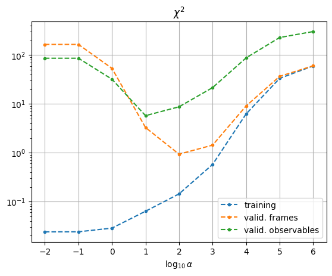

```python
plt.plot(log10_alphas, red_chi2s, '.--', label = 'training')
plt.plot(log10_alphas, red_chi2s_valid1, '.--', label = 'valid. frames')
plt.plot(log10_alphas, red_chi2s_valid2, '.--', label = 'valid. observables')

plt.legend()
plt.title('$\chi^2$')
plt.xlabel(r'$\log_{10}\alpha$')
plt.yscale('log')
plt.grid()
```

### d. Determine optimal hyper parameter $\alpha$ through cross validation (automatic optimization)

Rather than performing a scan over the hyperparameter $\alpha$, we now minimize the $\chi^2$ on the validation set (computed at optimal parameters obtained in training) with respect to $\alpha$.

```python
starting_alpha = 10**5
```

By default, it is `which_set = 'valid_frames'` (rather than `'validation'` or `'training'`), namely the cross validation is performed on the $\chi^2$ evaluated on the same observables as training but left-out frames of the trajectory (you can also select `which_set = 'validation'`, which means, $\chi^2$ on left-out observables).

```python
mini = hyper_minimizer(data, starting_alpha=starting_alpha, random_states=2, which_set='valid_frames', gtol=0.5)
```

[output not shown]

```
Input random_state employed both for observables and frames
```

```
log10 hyperpars:  [('alpha', np.float64(4.999999999999999))]
```

```
av. chi2:  25609.441377385963
av. gradient:  [36812.50251812]

log10 hyperpars:  [('alpha', np.float64(3.999999999999999))]
```

```
av. chi2:  4492.494163300984
av. gradient:  [8144.29200256]

log10 hyperpars:  [('alpha', np.float64(3.7159120902179077))]
```

```
av. chi2:  2729.571165511398
av. gradient:  [4559.41652373]

log10 hyperpars:  [('alpha', np.float64(3.3545954649395573))]
```

```
av. chi2:  1573.460739417288
av. gradient:  [2142.4017966]

log10 hyperpars:  [('alpha', np.float64(3.034330396444868))]
```

```
av. chi2:  1082.405259184729
av. gradient:  [1036.25025271]

log10 hyperpars:  [('alpha', np.float64(2.7343039127385564))]
```

```
av. chi2:  865.8147932981534
av. gradient:  [462.21203914]

log10 hyperpars:  [('alpha', np.float64(2.4927244332707423))]
```

```
av. chi2:  772.1943621917183
av. gradient:  [263.87038379]

log10 hyperpars:  [('alpha', np.float64(2.171331179522164))]
```

```
av. chi2:  730.3476206422108
av. gradient:  [23.70167811]

log10 hyperpars:  [('alpha', np.float64(2.139613644025412))]
```

```
av. chi2:  730.1378674165185
av. gradient:  [5.41653246]
```

```python
mini
```

```
      message: CONVERGENCE: RELATIVE REDUCTION OF F <= FACTR*EPSMCH
      success: True
       status: 0
          fun: 730.1378674165185
            x: [ 2.140e+00]
          nit: 8
          jac: [ 5.417e+00]
         nfev: 9
         njev: 9
     hess_inv: <1x1 LbfgsInvHessProduct with dtype=float64>
 intermediate: <MDRefine.hyperminimizer.hyper_minimizer.<locals>.hyper_intermediate_class object at 0x7f223829daf0>
```

```python
optimal_alpha = 10**(mini.x)

print(optimal_alpha)
```

```
[137.91567967]
```

This optimal value of the hyperparameter is compatible with that reported in the previous plot. We can now minimize the loss function at this optimal value.

```python
Result = minimizer(data, alpha=optimal_alpha)
```

[output not shown]

### e. Do all together with `MDRefinement`

All these steps are consequentially performed by `MDRefinement`, which first loads the stored data, then determine the optimal hyperparameters through automatic minimization of validation $\chi^2$ and finally minimize the loss function at optimized value of the hyperparameter.

```python
Result = MDRefinement(data_cv, stride=stride, starting_alpha=1e5, random_states=2, which_set='validation', gtol=0.5)
```

[output not shown]

```
Input random_state employed both for observables and frames
```

```
log10 hyperpars:  [('alpha', np.float64(4.999999999999999))]
```

```
av. chi2:  24135.674752701867
av. gradient:  [30407.41046598]

log10 hyperpars:  [('alpha', np.float64(3.999999999999999))]
```

```
av. chi2:  3809.1778136834455
av. gradient:  [8427.79335971]

log10 hyperpars:  [('alpha', np.float64(3.61656323133563))]
```

```
av. chi2:  1662.3058569797408
av. gradient:  [3395.30564013]

log10 hyperpars:  [('alpha', np.float64(3.3578671160491145))]
```

```
av. chi2:  1020.1836304788742
av. gradient:  [1751.51676059]

log10 hyperpars:  [('alpha', np.float64(3.0822170082638554))]
```

```
av. chi2:  678.5772878837165
av. gradient:  [841.37486179]

log10 hyperpars:  [('alpha', np.float64(2.82739402775131))]
```

```
av. chi2:  521.6479057786999
av. gradient:  [435.61673066]

log10 hyperpars:  [('alpha', np.float64(2.553819340881816))]
```

```
av. chi2:  435.1074547641106
av. gradient:  [224.61546486]

log10 hyperpars:  [('alpha', np.float64(2.262593099982632))]
```

```
av. chi2:  389.43946173852584
av. gradient:  [100.94401948]

log10 hyperpars:  [('alpha', np.float64(2.024886269240827))]
```

```
av. chi2:  371.33007701987805
av. gradient:  [25.33942282]

optimal hyperparameters: alpha: 105.89763696898787

refinement with optimal hyperparameters...
```

```
done
```

```python
vars(Result)
```

[output not shown]

[output cut: 303 more lines]

[output not shown]

Here, you can look at the values contained in `Result` as previously done in Section b.